# Beach Tan Explanatory Analysis

Peter Fortunato

10/1/2020

## 1 Introduction and Data Dictionary

Beach Tan Inc. is a major national franchiser of tanning salons. Their two main products include "UV Tans", which are offered in tanning beds or stand-up booths, and "Sunless Tans", which are provided via a spray-on solution and do not expose the user to any UV tans.

In addition to their two methods of tanning, Beach Tan Inc. also sells specially formulated skin care products that can enhance the quality and duration of tanning results.

Beach Tan Inc. also offers a convenient membership program allows clients more control over their decision-making power.

### 1.1 Reading in the data

The csv file containing the Beach Tan data resides in this project directory.

```r
# Loading the library that reads in csv files
library(readr)

# Reading in the Beach Tan dataset
beach <- read.csv("BeachTan/BeachTan.csv")

# Viewing the head of the data
head(beach)
```

```
##   UIDClient UIDStoreLocation Gender DateJoined DaysSinceJoined MembershipType
## 1       597                1      0    3/13/10            1694              2
## 2     17873                1      0    10/3/09            1855              2
## 3     26441                1      0    3/18/07            2785              2
## 4     31132                1      0    3/18/07            2785              2
## 5     31382                1      0    4/24/12             921              2
## 6     44204                1      0    6/22/07            2689              2
##   MembershipLevel Age UVTans SunlessTans UpgradeRevenue RetailRevenue
## 1               0  38    189           4             56         76.01
## 2               0  48      0          26             25        171.32
## 3               1  76    265          58             15        190.23
## 4               0  40    327          18              0        399.58
## 5               0  20     90           0              8         66.99
## 6               0  20    162          17              0        323.16
```

### 1.2 Variable Overview

```r
# Viewing the structure of the data
str(beach)
```

```
## 'data.frame':    11041 obs. of  12 variables:
##  $ UIDClient       : int  597 17873 26441 31132 31382 44204 50652 81049 98231 9020 ...
##  $ UIDStoreLocation: int  1 1 1 1 1 1 1 1 1 2 ...
##  $ Gender          : int  0 0 0 0 0 0 0 0 0 0 ...
##  $ DateJoined      : chr  "3/13/10" "10/3/09" "3/18/07" "3/18/07" ...
##  $ DaysSinceJoined : int  1694 1855 2785 2785 921 2689 2351 2053 1591 1160 ...
##  $ MembershipType  : int  2 2 2 2 2 2 2 2 2 2 ...
##  $ MembershipLevel : int  0 0 1 0 0 0 0 4 0 1 ...
##  $ Age             : int  38 48 76 40 20 20 52 40 63 21 ...
##  $ UVTans          : int  189 0 265 327 90 162 2 34 11 306 ...
##  $ SunlessTans     : int  4 26 58 18 0 17 1 2 0 0 ...
##  $ UpgradeRevenue  : int  56 25 15 0 8 0 0 0 0 0 ...
##  $ RetailRevenue   : num  76 171 190 400 67 ...
```

This data frame of 11,041 observations and 12 variables was collected in 2014. According to the data dictionary, the variables in the model include:

- **UIDClient**: Client Indentification Number
- **UIDStoreLocation**: Store Identification Number (10 include in this data set)
- **Gender**: 0 = Female, 1 = Male
- **DateJoined**: Date the client joined (if non-member this is the date of their first tanning session)
- **DaysSinceJoined**: The number of days elapsed between DateJoined and 11/01/2014
- **MembershipType**: 0 = Non-Member, 1 = Monthly Membership, 2 = Annual Membership
- **MembershipLevel**: This variable corresponds to the strength and quality of tanning equipment offered to clients on what level of membership they have. Better equipment means faster tanning results. 0 = Non-Member, 1 = Fast, 2 = Faster, 3 = Fastest, 4 = Instant
- **Age**: The age of client in years
- **UVTans**: The number of UV Tans a client has received since joining Beach Tan
- **SunlessTans**: The number of Sunless Tans a client has received since joining Beach Tan
- **UpgradedRevenue**: The amount of extra money spent (in dollars) by members to tan in a higher level bed than what their regular membership would include.
- **RetailRevenue**: The amound of money spent (in dollars) by any client on various skin car lotions and products offered by Beach Tan

Looking at the structure of the Beach Tan data frame and understanding the information presented within the variables, it's clear that I will need to change the format of some of the variables. However, I will get to that in another section.

## 2 Analysis Preview and Revision of Business Value Proposition

### 2.1 Reasons for Revising Business Value Proposition

In my original Business Value Proposition, I outlined how the two main products that I would deliver with my analysis were a predictive model to understand future clients' spend as well as a visualization dashboard to help non-members understand how their spending habbits would be better suited if they were to become a member.

After working with this data set for some time, I've come to the conclusion that neither of those two products are feasible. The predictive model cannot be done for there are no new observations in which to predict their total Retail Revenue. And for the visualization dashboard, the data doesn't really explain how much members are saving versus non-members.

It is for these reasons that I have decided to change the product which I will be offering. Instead of a predictive model and visualization dashboard, I shall conduct two explanatory analyses in order to understand two things: the variables that explain Retail Revenue as well as the variables that explain Upgraded Revenue.

### 2.2 Revised Business Value Proposition 1

[figure not shown]

BVP 1

## 3 Data Manipulation, Exploration and Preparation

### 3.1 Reformatting variables to factors

As I explained previously, there are a number of variables that need to be reformatted in order for the models to accurately analyze the data. The variables UIDStoreLocation, Gender, MembershipType, and MembershipLevel are currently formatted as numeric and must be changed to factors. The variable DateJoined is currently formatted as a character and needs to be changed to a date variable.

```r
# changing the following numeric variables to factors
beach$UIDStoreLocation <- as.factor(beach$UIDStoreLocation)
beach$Gender <- as.factor(beach$Gender)
beach$MembershipType <- as.factor(beach$MembershipType)
beach$MembershipLevel <- as.factor(beach$MembershipLevel)

# changing the following character variable to a date
beach$DateJoined <- as.Date(beach$DateJoined, "%m/%d/%Y")
```

### 3.2 Recoding factors to reflect their information

Next, I'm going to recode the new factors so that they say their actual level as opposed to just using a number that corresponds to their level. I will also recode the UIDStoreLocation variable so that it's labels are more agreeable to code. When I create dummy variables for these factors later on, this will help make them easier to understand in the model output.

The tidyverse package contains a variaty of packages that will assist me in my analysis. I will preface any use of a function with the package that it comes from. For example, the function `recode_factor` belongs to the dplyr package in the tidyverse family.

```r
# Loading in the tidyverse package
library(tidyverse)
# Recoding the factors in Gender
beach$Gender <- recode_factor(beach$Gender,
                              "0" = "Female",
                              "1" = "Male")

# Recoding the factors in MemebershipType
beach$MembershipType <- recode_factor(beach$MembershipType,
                                      "0" = "Non-Member",
                                      "1" = "Monthly",
                                      "2" = "Annual")

# Recoding the factors in MembershipLevel
beach$MembershipLevel <- recode_factor(beach$MembershipLevel,
                                       "0" = "Non-Member",
                                       "1" = "Fast",
                                       "2" = "Faster",
                                       "3" = "Fastest",
                                       "4" = "Instant")

# Recoding the factors in UIDStoreLocation
beach$UIDStoreLocation <- recode_factor(beach$UIDStoreLocation,
                                         "1" = "A",
                                         "2" = "B",
                                         "3" = "C",
                                         "4" = "D",
                                         "5" = "E",
                                         "6" = "F",
                                         "7" = "G",
                                         "8" = "H",
                                         "9" = "I",
                                         "10" = "J")
```

### 3.3 Creating summary visualizations of the continuous and categorical variables and removing ununusal observations/unneeded variables

Now that the variables in the data are properly formatted, we can take an accurate overview of the data with help from the DataExplorer package. I want to first explore the distribution of missing values in the data set.

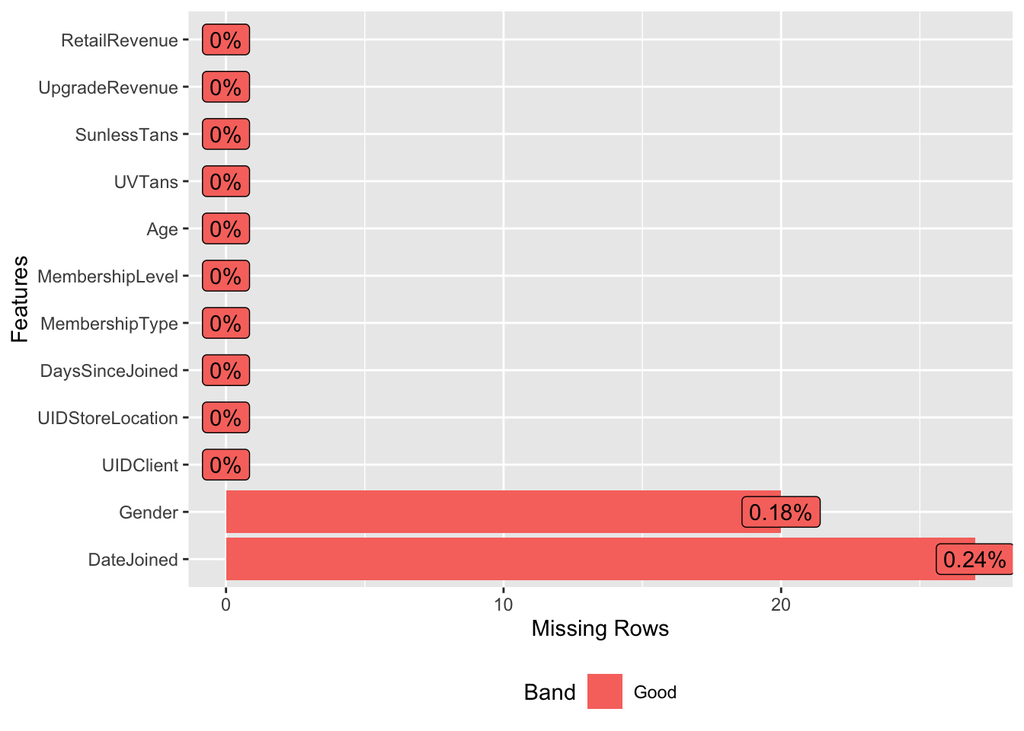

```r
# Loading the DataExplorer package
library(DataExplorer)

plot_missing(beach)
```

Here is the distribution of continuous variables.

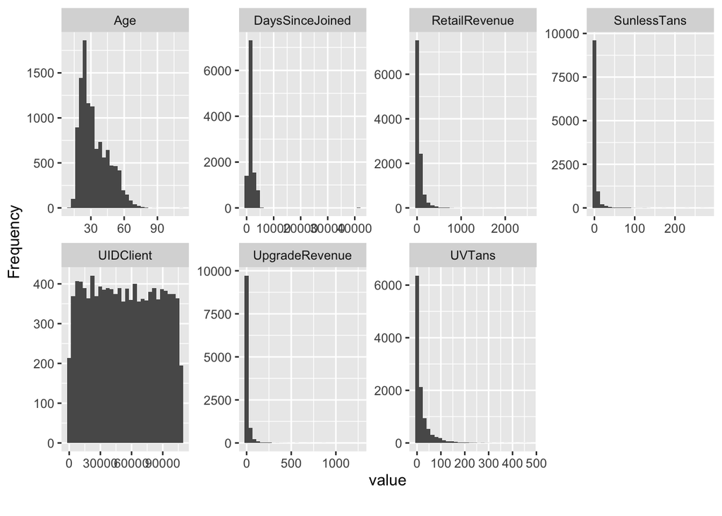

```r
# Distribution of the continuous variables
plot_histogram(beach)
```

There are a couple things I need to point out. First, UIDClient appears to be an unhelpful variable. This is likely due to the fact that each client has a unique ID number, making this information not useful when making a model. It's best to just remove UIDClient from the data.

```r
# The piping operator (%>%) and `select` functions belong to the dplyr package
beach <- beach %>%
  select(-UIDClient)
```

Second, the histogram for DaysSinceJoined appears to have values above 40,000, which indicates that some members/customers joined over 100 years ago. Let's see what's going on with these rows.

```r
# The `filter` function belongs to the dplyr package
filter(beach, DaysSinceJoined > 40000)
```

```
##    UIDStoreLocation Gender DateJoined DaysSinceJoined MembershipType
## 1                 A Female       <NA>           41944        Monthly
## 2                 A Female       <NA>           41944        Monthly
## 3                 B Female       <NA>           41944        Monthly
## 4                 C Female       <NA>           41944        Monthly
## 5                 C Female       <NA>           41944        Monthly
## 6                 D Female       <NA>           41944        Monthly
## 7                 D Female       <NA>           41944        Monthly
## 8                 D Female       <NA>           41944        Monthly
## 9                 D Female       <NA>           41944        Monthly
## 10                D Female       <NA>           41944        Monthly
## 11                I Female       <NA>           41944        Monthly
## 12                I Female       <NA>           41944        Monthly
## 13                I Female       <NA>           41944        Monthly
## 14                A Female       <NA>           41944     Non-Member
```

[output cut: 41 more lines]

It's clear from this output that for each of these observations, DateJoined is missing. In fact, these are all of the 27 rows in which DateJoined is missing, and 27/11041 = 0.0024 or 0.24%. These rows could adversely affect the models, so it's a good idea to just remove them from the data.

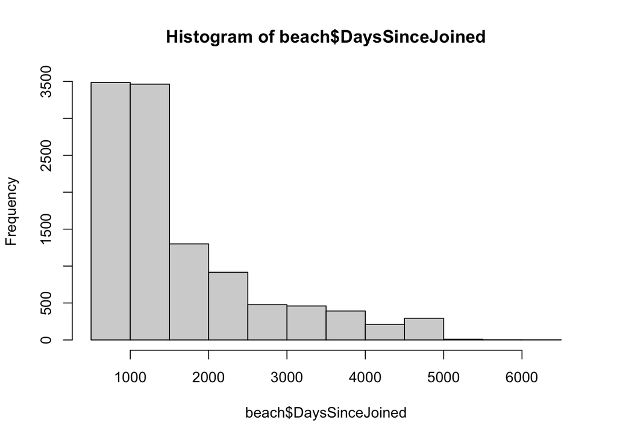

```r
beach <- beach %>%
  filter(DaysSinceJoined < 40000)

hist(beach$DaysSinceJoined)
```

This distribution of DaysSinceJoined now looks more realistic.

While we are at it, we should also remove DateJoined from the data, as it will complicate the model and that type of information is already stored in the DaysSinceJoined variable.

```r
beach <- beach %>%
  select(-DateJoined)
```

Now let's look at the distribution of the categorical variables.

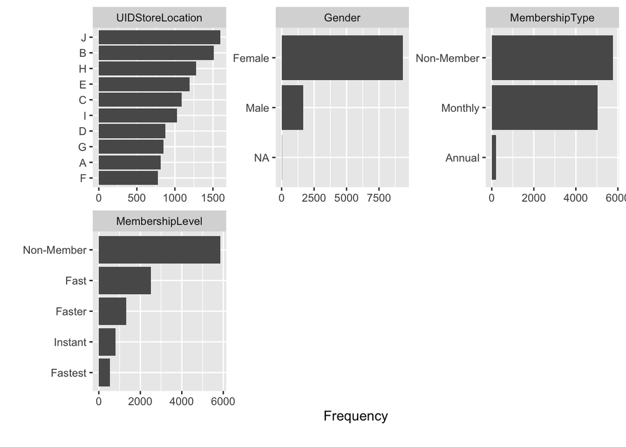

```r
# Distribution of factors
plot_bar(beach)
```

It's clear that Female and Non-Member customers make up the majority of the clientel of Beach Tan Inc.

The Gender variable has a coule of N/A values, and there's no point in making an extra dummy variable for a level of a factor that has a miniscule number of obersvations, so I'm going to remove those rows as well.

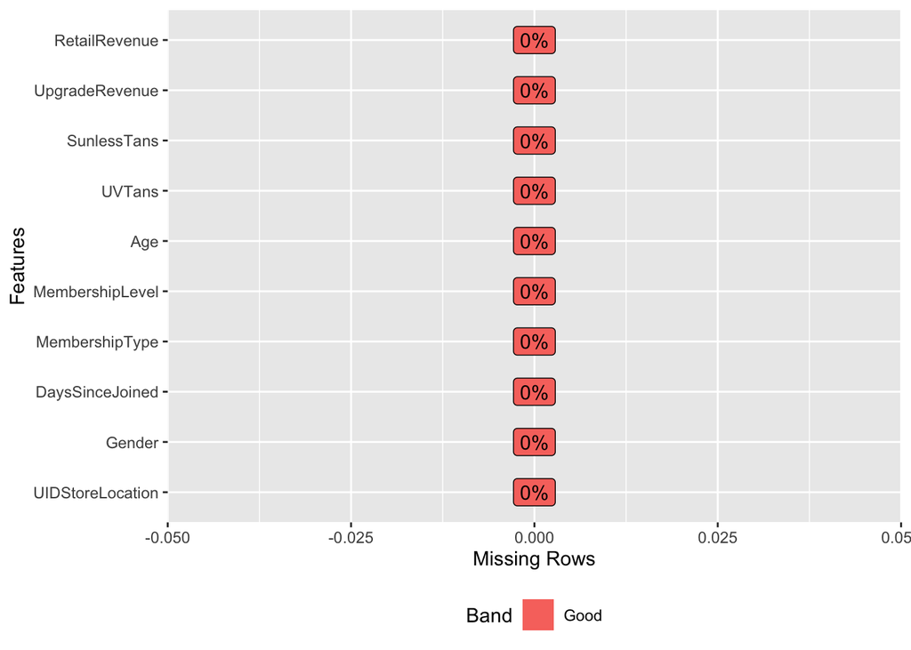

```r
# The `na_omit` function belongs to the stats package.
beach <- na.omit(beach)
plot_missing(beach)
```

Now we have a data set with exactly 0 missing rows.

## 4 Aggregated Visualizations

The purpose of these visualizations is to analyze trends between either Retail Revenue or Upgrade Revenue (the response variables for the two models I will be making) and various predictor variables. While they won't have the same analytical power as the mdoels, they will still provide valuable insight for Beach Tan Inc.

For these visualizations, I will be using functions from the `ggplot2` package from the `tidyverse` family.

### 4.1 Total Retail Revenue by Store Location

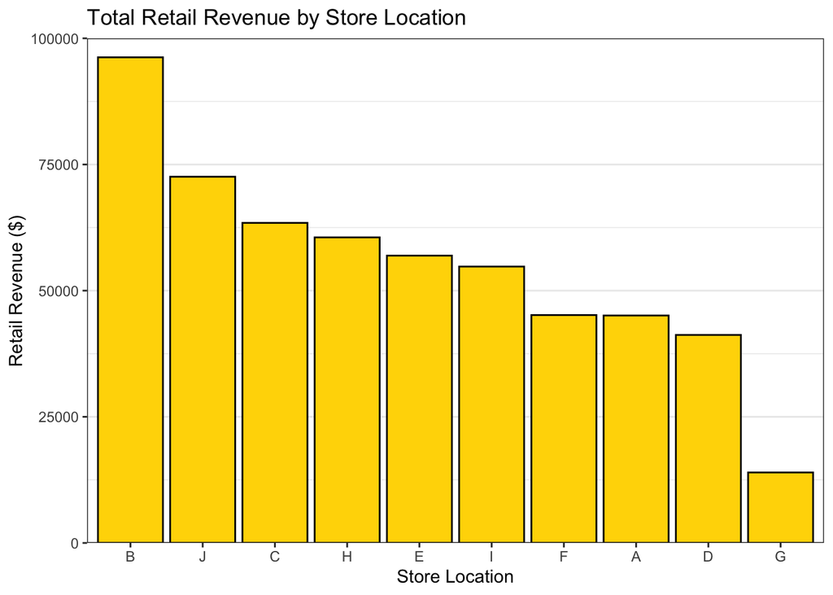

```r
# Aggregating Retail Revenue by Store Location
storesum <- aggregate(RetailRevenue~UIDStoreLocation, beach, sum)

# Creating a plot and assigning it to an object
p1 <- ggplot(storesum, aes(x = reorder(UIDStoreLocation, -RetailRevenue), y = RetailRevenue)) +
  geom_col(colour = "black", fill = "gold") +
  scale_y_continuous(expand = c(0,0),
                     limits = c(0, 100001),
                     breaks = c(0, 25000, 50000, 75000, 100000)) +
  ylab("Retail Revenue ($)") +
  xlab("Store Location") +
  labs(title = "Total Retail Revenue by Store Location") +
  theme_bw() +
  theme(
    panel.grid.major.x = element_blank(),
    panel.grid.minor.x = element_blank()
  )

p1
```

It appears from this graph that Store B is perfoming the best by a considerable margin and Store G is performing the worst by a very large margin. If I were consulting the executives of Beach Tan Inc, I would advise them to consider closing Store G for it is lagging far behind the rest of the pack.

Averaging Retail Revenue by the number of customers each store brings in, I can see a similar story: Store G is simply not performing well.

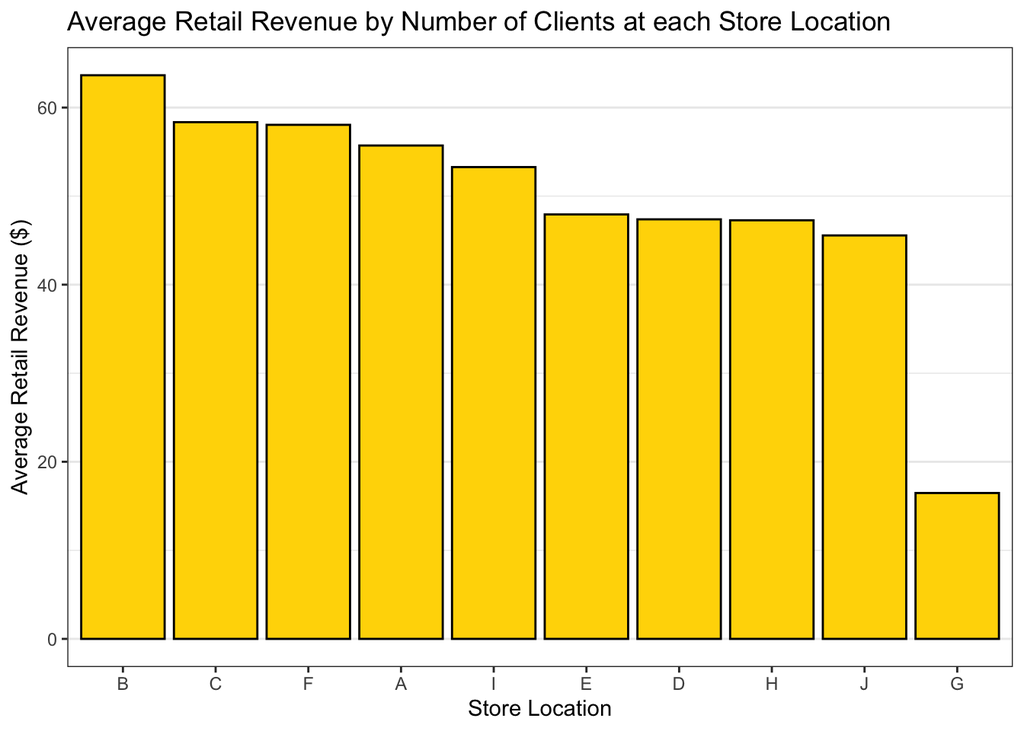

```r
# Aggregating Average Retail Revenue by Store Location
storemean <- aggregate(RetailRevenue~UIDStoreLocation, beach, mean)

# Creating a plot and assigning it to an object
p2 <- ggplot(storemean, aes(x = reorder(UIDStoreLocation, -RetailRevenue), y = RetailRevenue)) +
  geom_col(colour = "black", fill = "gold") +
  ylab("Average Retail Revenue ($)") +
  xlab("Store Location") +
  labs(title = "Average Retail Revenue by Number of Clients at each Store Location") +
  theme_bw() +
  theme(
    panel.grid.major.x = element_blank(),
    panel.grid.minor.x = element_blank()
  )

p2
```

### 4.2 Total Retail Revenue by Membership Level

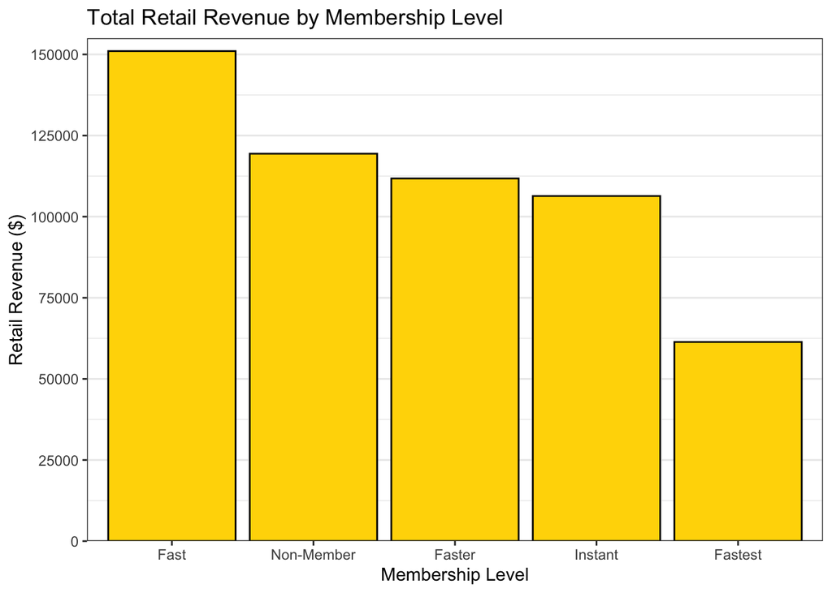

```r
# Aggregating Retail Revenue by Membership Level
levelsum <- aggregate(RetailRevenue~MembershipLevel, beach, sum)

# Creating a plot and assigning it to an object
p3 <- ggplot(levelsum, aes(x = reorder(MembershipLevel, -RetailRevenue), y = RetailRevenue)) +
  geom_col(colour = "black", fill = "gold") +
  scale_y_continuous(expand = c(0,0),
                     limits = c(0, 155000),
                     breaks = c(0, 25000, 50000, 75000, 100000, 125000, 150000)) +
  ylab("Retail Revenue ($)") +
  xlab("Membership Level") +
  labs(title = "Total Retail Revenue by Membership Level") +
  theme_bw() +
  theme(
    panel.grid.major.x = element_blank(),
    panel.grid.minor.x = element_blank()
  )

p3
```

### 4.3 Total Retail Revenue by Membership Type

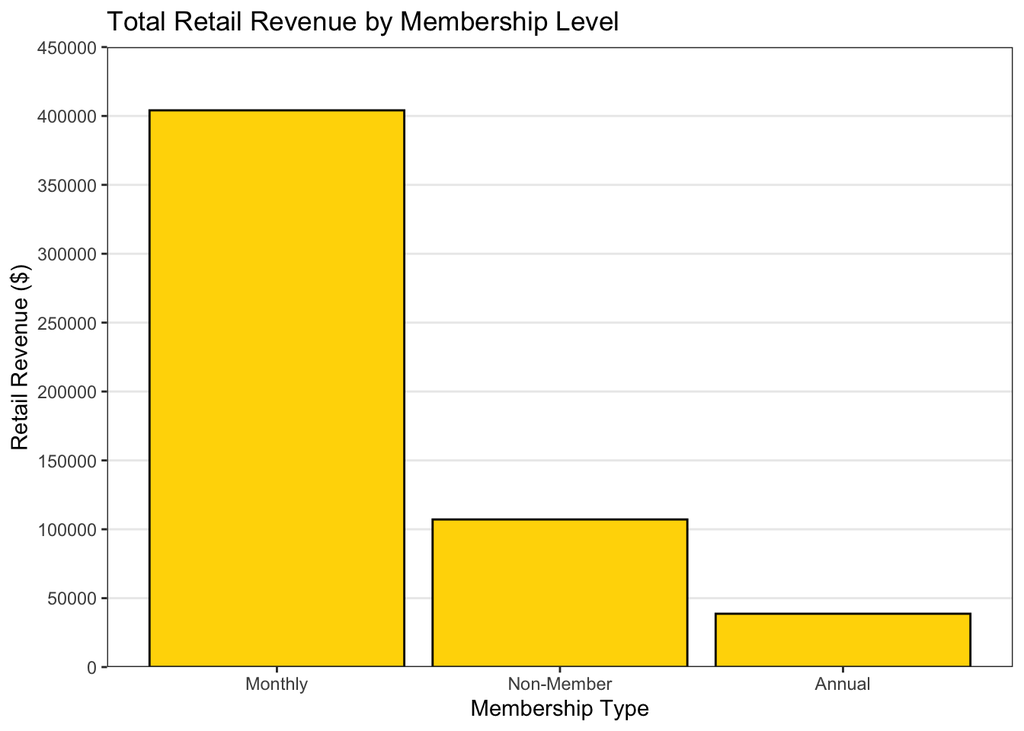

```r
# Aggregating Retail Revenue by Membership Type
typesum <- aggregate(RetailRevenue~MembershipType, beach, sum)

# Creating a plot and assigning it to an object
p4 <- ggplot(typesum, aes(x = reorder(MembershipType, -RetailRevenue), y = RetailRevenue)) +
  geom_col(colour = "black", fill = "gold") +
  scale_y_continuous(expand = c(0,0),
                     limits = c(0, 450000),
                     breaks = seq(from = 0, to = 450000, by = 50000)) +
  ylab("Retail Revenue ($)") +
  xlab("Membership Type") +
  labs(title = "Total Retail Revenue by Membership Level") +
  theme_bw() +
  theme(
    panel.grid.major.x = element_blank(),
    panel.grid.minor.x = element_blank(),
    panel.grid.minor.y = element_blank()
  )

p4
```

From this visualization, I can clearly see that customers with Monthly Memberships are far and away the drivers of Revenue for Beach Tan Inc.

### 4.5 Total Upgraded Revenue by Membership Level

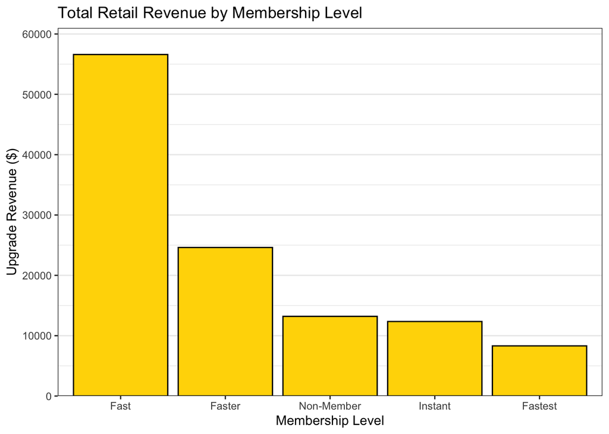

```r
# Aggregating Upgrade Revenue by Membership Level
levelsum1 <- aggregate(UpgradeRevenue~MembershipLevel, beach, sum)

# Creating a plot and assigning it to an object
p5 <- ggplot(levelsum1, aes(x = reorder(MembershipLevel, -UpgradeRevenue), y = UpgradeRevenue)) +
  geom_col(colour = "black", fill = "gold") +
  scale_y_continuous(expand = c(0,0),
                     limits = c(0, 61000),
                     breaks = c(0, 10000, 20000, 30000, 40000, 50000, 60000, 70000)) +
  ylab("Upgrade Revenue ($)") +
  xlab("Membership Level") +
  labs(title = "Total Retail Revenue by Membership Level") +
  theme_bw() +
  theme(
    panel.grid.major.x = element_blank(),
    panel.grid.minor.x = element_blank()
  )

p5
```

## 5 Model Preparation

### 5.4 Creating Dummy Variables

In order to allow the data to be more conducive to the model, I will be manually creating dummy variables for each of the factors in the data set.

```r
# Creating dummy variables for factors in the data frame
dum1 <- model.matrix(~0 + UIDStoreLocation, data = beach)
dum1 <- as.data.frame(dum1)

dum2 <- model.matrix(~0 + Gender, data = beach)
dum2 <- as.data.frame(dum2)

dum3 <- model.matrix(~0 + MembershipType, data = beach)
dum3 <- as.data.frame(dum3)

dum4 <- model.matrix(~0 + MembershipLevel, data = beach)
dum4 <- as.data.frame(dum4)
```

```r
# Adding dummy variables to the data frame

beach <- cbind(beach, dum1, dum2, dum3, dum4)

colnames(beach)
```

```
##  [1] "UIDStoreLocation"          "Gender"
##  [3] "DaysSinceJoined"           "MembershipType"
##  [5] "MembershipLevel"           "Age"
##  [7] "UVTans"                    "SunlessTans"
##  [9] "UpgradeRevenue"            "RetailRevenue"
## [11] "UIDStoreLocationA"         "UIDStoreLocationB"
## [13] "UIDStoreLocationC"         "UIDStoreLocationD"
## [15] "UIDStoreLocationE"         "UIDStoreLocationF"
## [17] "UIDStoreLocationG"         "UIDStoreLocationH"
## [19] "UIDStoreLocationI"         "UIDStoreLocationJ"
## [21] "GenderFemale"              "GenderMale"
## [23] "MembershipTypeNon-Member"  "MembershipTypeMonthly"
## [25] "MembershipTypeAnnual"      "MembershipLevelNon-Member"
## [27] "MembershipLevelFast"       "MembershipLevelFaster"
## [29] "MembershipLevelFastest"    "MembershipLevelInstant"
```

# Removing original variables plus one dummy for each factor

```r
beach1 <- beach %>%
  select(-UIDStoreLocation, -Gender, -MembershipType, -MembershipLevel,
         -UIDStoreLocationA, -GenderMale, -MembershipLevelInstant, MembershipTypeAnnual)
```

```r
# Recoding each dummy variable as factors

beach$UIDStoreLocationB <- as.factor(beach$UIDStoreLocationB)
beach$UIDStoreLocationC <- as.factor(beach$UIDStoreLocationC)
beach$UIDStoreLocationD <- as.factor(beach$UIDStoreLocationD)
beach$UIDStoreLocationE <- as.factor(beach$UIDStoreLocationE)
beach$UIDStoreLocationF <- as.factor(beach$UIDStoreLocationF)
beach$UIDStoreLocationG <- as.factor(beach$UIDStoreLocationG)
beach$UIDStoreLocationH <- as.factor(beach$UIDStoreLocationH)
beach$UIDStoreLocationI <- as.factor(beach$UIDStoreLocationI)
beach$UIDStoreLocationJ <- as.factor(beach$UIDStoreLocationJ)
beach$GenderFemale <- as.factor(beach$GenderFemale)
beach$`MembershipTypeNon-Member` <- as.factor(beach$`MembershipTypeNon-Member`)
beach$MembershipTypeMonthly <- as.factor(beach$MembershipTypeMonthly)
beach$MembershipLevelFast <- as.factor(beach$MembershipLevelFast)
beach$MembershipLevelFaster <- as.factor(beach$MembershipLevelFaster)
beach$MembershipLevelFastest <- as.factor(beach$MembershipLevelFastest)
beach$`MembershipLevelNon-Member` <- as.factor(beach$`MembershipLevelNon-Member`)
```

```r
beachRetail <- beach1 %>%
  select(-UpgradeRevenue)

beachUpgrade <- beach1 %>%
  select(-RetailRevenue, -`MembershipTypeNon-Member`, -`MembershipLevelNon-Member`)
```